# GDF7302 - Statistiques

Philippe Marchand

12 juillet 2018

# Objectifs

- Connaître les différents rôles des méthodes statistiques.
- Comprendre des concepts de base liés aux statistiques descriptives et aux problèmes d’estimation, de prédiction et de test d’hypothèse.
- Pouvoir interpréter les résultats d’analyses statistiques courantes dans la littérature scientifique.

# Différents rôles des statistiques

- *Décrire* les caractéristiques sommaires d’un ensemble de données.
- À partir de mesures prises sur un échantillon d’individus, *estimer* les caractéristiques d’une variable, ou d’une relation entre variables, au niveau de la population.
- *Tester* une hypothèse portant sur ces variables ou relations entre variables.
- *Prédire* la valeur d’une variable pour un nouvel individu hors de l’échantillon.

# Exemples de questions

- Quel est le diamètre moyen des arbres mesurés dans une parcelle?
- Quel est le taux de chômage à Rouyn-Noranda? Combien d’emplois seront créés l’an prochain?
- Combien y a-t-il d’orginaux dans le Parc de la Vérendrye? La population est-elle en croissance par rapport à l’année précédente?

# Statistiques descriptives

Prenons une série de données $x_1$, $x_2$, …, $x_n$ provenant d’une variable $x$ mesurée sur $n$ individus.

## Moyenne

$E[x] = \frac{x_1 + x_2 + ... + x_n}{n} = \frac{\sum_{i = 1}^{n} x_i}{n}$

# Statistiques descriptives

Prenons une série de données $x_1$, $x_2$, …, $x_n$ provenant d’une variable $x$ mesurée sur $n$ individus.

## Moyenne

$E[x] = \frac{x_1 + x_2 + ... + x_n}{n} = \frac{\sum_{i = 1}^{n} x_i}{n}$

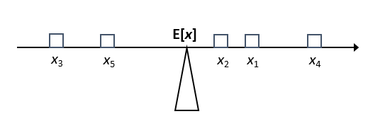

# Statistiques descriptives

## Écart à la moyenne

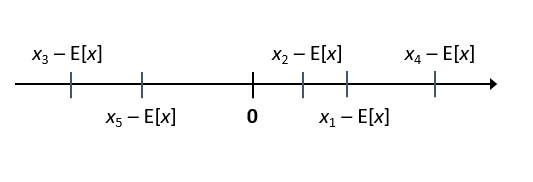

# Statistiques descriptives

## Écart à la moyenne

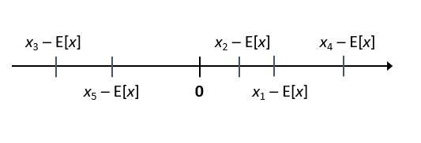

## Variance

$\sigma_x^2 = \frac{\sum_{i = 1}^{n} (x_i - E[x])^2}{n}$

# Statistiques descriptives

## Écart-type

$\sigma_x = \sqrt{\frac{\sum_{i = 1}^{n} (x_i - E[x])^2}{n}}$

# Statistiques descriptives

## Écart-type

$\sigma_x = \sqrt{\frac{\sum_{i = 1}^{n} (x_i - E[x])^2}{n}}$

**Note**: Lorsqu’on veut estimer la variance ou l’écart-type d’une population à partir d’un échantillon, on divise par $n-1$ plutôt que $n$.

# Statistiques descriptives

Statistiques basées sur le rang des données (en ordre croissant)

- Minimum et maximum
- Médiane
- Quantiles: divisent les données en $m$ groupes de la même taille
  - Exemples: quartile ($m$ = 4), quintiles ($m$ = 5), centiles ($m$ = 100).

# Boîte à moustache (*boxplot*)

Représentation graphique basée sur les quartiles

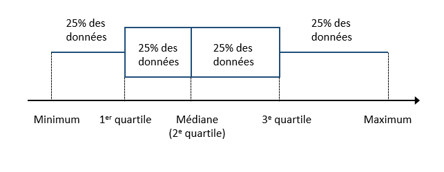

# Boîte à moustache (*boxplot*)

Représentation graphique basée sur les quartiles

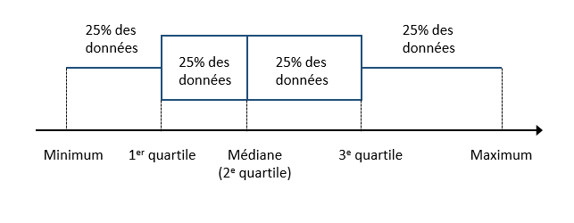

Parfois, les valeurs extrêmes situées au-delà d’une certaine distance des quartiles sont représentées par des points séparés de la moustache.

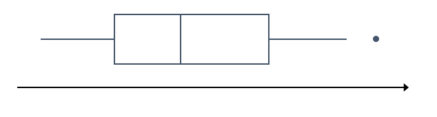

# Histogramme

Divise l’axe des données en intervalles de même largeur et compte le nombre d’observations dans chaque intervalle.

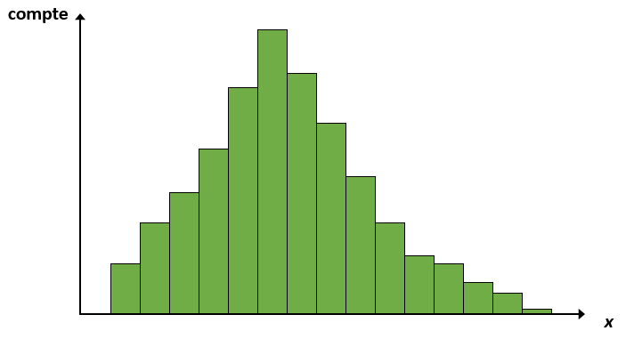

# Histogramme

Divise l’axe des données en intervalles de même largeur et compte le nombre d’observations dans chaque intervalle.

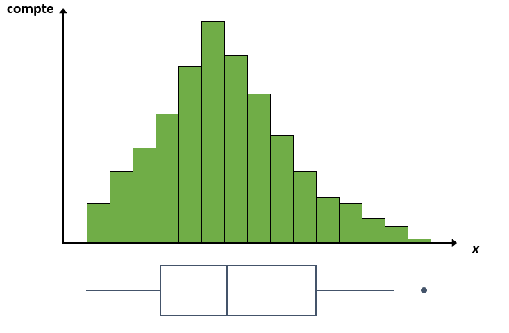

# Exemple

- Jeu de données `CO2` inclus avec le logiciel R.
- Mesure du taux d’assimilation du CO$_2$ (*uptake*) en fonction de la concentration de CO$_2$ dans l’air (*conc*), pour des plants d’*Echinochloa crus-galli* provenant de deux populations différentes (Québec ou Mississippi) et soumis à deux traitements (refroidi ou non).

```
##    Plant        Type  Treatment conc uptake
## 54   Mn2 Mississippi nonchilled  500   32.4
## 72   Mc2 Mississippi    chilled  175   11.4
## 64   Mc1 Mississippi    chilled   95   10.5
## 51   Mn2 Mississippi nonchilled  175   22.0
## 9    Qn2      Quebec nonchilled  175   27.3
## 11   Qn2      Quebec nonchilled  350   41.8
## 10   Qn2      Quebec nonchilled  250   37.1
## 49   Mn1 Mississippi nonchilled 1000   35.5
## 5    Qn1      Quebec nonchilled  500   35.3
## 47   Mn1 Mississippi nonchilled  500   30.9
```

Source: Potvin, C. *et al.* 1990. The Statistical Analysis of Ecophysiological Response Curves Obtained from Experiments Involving Repeated Measures. *Ecology* 71, pp.1389-1400.

# Exemple

```
## # A tibble: 4 x 5
## # Groups:   Type [?]
##   Type        Treatment  `median(uptake)` `mean(uptake)` `sd(uptake)`
##   <fct>       <fct>                 <dbl>          <dbl>        <dbl>
## 1 Quebec      nonchilled             39.2           35.3         9.60
## 2 Quebec      chilled                35             31.8         9.64
## 3 Mississippi nonchilled             28.1           26.0         7.40
## 4 Mississippi chilled                17.9           15.8         4.06
```

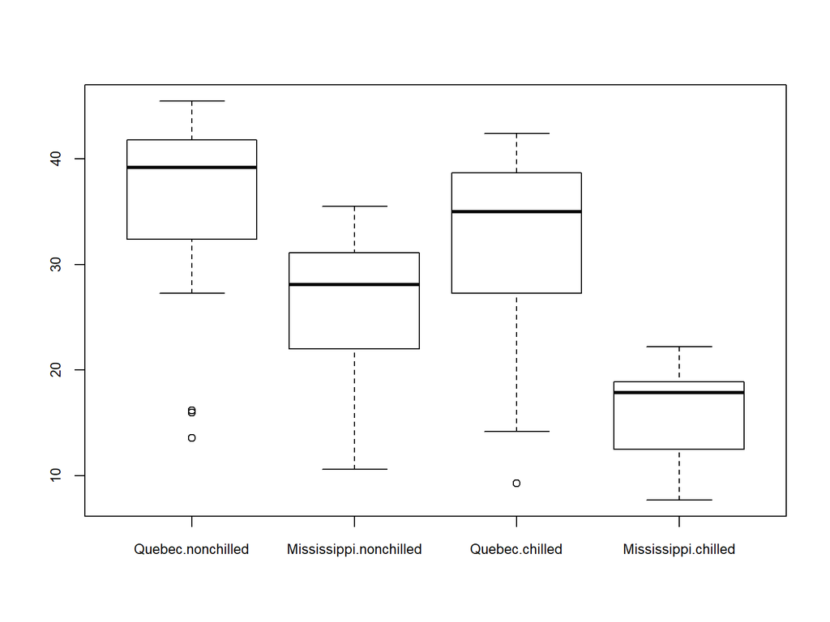

# Corrélation

Prenons deux variables $x$ et $y$ observées sur les mêmes individus.

- La corrélation (généralement notée $r$ ou $\rho$) mesure l’association entre les valeurs de $x$ et $y$ par rapport à leur moyenne respective.
- Si les valeurs élevées de $x$ sont plus souvent associées aux valeurs élevées de $y$, la corrélation est positive. Dans le cas contraire ($x$ est moindre quand $y$ est élevée et vice versa), la corrélation est négative.
- La corrélation est définie de manière à être toujours comprise entre -1 et 1.
- Pour deux variables indépendantes (sans relation entre elles), la corrélation est zéro, mais l’inverse n’est pas nécessairement le cas.

# Corrélation

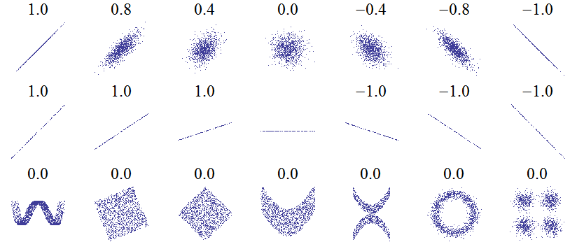

# Modèles statistiques

- Afin de généraliser les observations prises sur un échantillon à une population, on a besoin d’un *modèle*; une représentation abstraite et simplifiée du système que l’on étudie.
- En statistique, la modélisation requiert d’assigner une *distribution* à chaque variable mesurée.
- Exemple: distribution normale pour une variable continue.

# Distribution normale

- Deux paramètres ajustables: moyenne $\mu$ et écart-type $\sigma$.
- Probabilité que $x$ soit compris dans l’intervalle $(\mu - \sigma, \mu + \sigma)$: $\approx$ 68%; dans l’intervalle $(\mu - 2 \sigma, \mu + 2 \sigma)$: $\approx$ 95%.

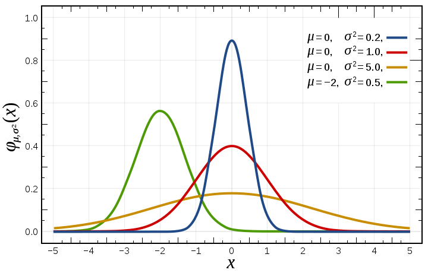

# Distributions pour des variables discrètes

- Distribution binomiale: donne la probabilité d’obtenir $x$ “succès” sur $N$ observations, si chaque observation a indépendamment une probabilité de succès $p$.
  - Exemple: Si on plante 50 semis et que 34 survivent l’année suivante, quelle est notre estimé du taux de survie?
- Distribution de Poisson: reliée à la distribution binomiale, mais plus pratique lorsque $N$ est très grand et $p$ très petite. Elle n’a qu’un seul paramètre, soit le nombre moyen d’événements observés.
  - Exemple: Le nombre de cas d’une maladie rare découverts au Canada chaque année.

# Estimation de paramètres

Supposons qu’une variable $x$ suit une distribution normale (moyenne $\mu$, écart-type $\sigma$). Avec quelle précision peut-on estimer $\mu$ à partir des mesures de $x$ sur un échantillon aléatoires de $n$ individus?

- La moyenne de $x$ calculée sur l’échantillon suit elle-même une distribution normale, avec une moyenne égale à $\mu$ et un écart-type égal à:

$\frac{\sigma}{\sqrt{n}}$

- Puisque cet écart-type représente la variation aléatoire de l’estimé d’un paramètre autour de sa “vraie” valeur, on l’appelle erreur-type (*standard error*).
- Cette formule est une bonne approximation de l’erreur-type de la moyenne de plusieurs distributions autres que la normale.

# Intervalle de confiance

- Connaissant l’erreur-type, on peut évaluer la probabilité que l’estimé de la moyenne (notons le $\bar{x}$) soit à une certaine distance de la moyenne de la population $\mu$.
- Par exemple, il y a une probabilité d’environ 95% que $\bar{x}$ se trouve à $\pm$ 1,96 erreurs-type de $\mu$.

$\left( \mu - 1,96 \frac{\sigma}{\sqrt{n}}, \mu + 1,96 \frac{\sigma}{\sqrt{n}}\right)$

# Intervalle de confiance

- Connaissant l’erreur-type, on peut évaluer la probabilité que l’estimé de la moyenne (notons le $\bar{x}$) soit à une certaine distance de la moyenne de la population $\mu$.
- Par exemple, il y a une probabilité d’environ 95% que $\bar{x}$ se trouve à $\pm$ 1,96 erreurs-type de $\mu$.

$\left( \mu - 1,96 \frac{\sigma}{\sqrt{n}}, \mu + 1,96 \frac{\sigma}{\sqrt{n}}\right)$

- On peut définir un *intervalle de confiance* à 95% pour $\bar{x}$:

$\left( \bar{x} - 1,96 \frac{\sigma}{\sqrt{n}}, \bar{x} + 1,96 \frac{\sigma}{\sqrt{n}}\right)$.

Pour 95% des échantillons possibles, $\mu$ sera compris à l’intérieur de l’intervalle défini ainsi.

- Toutefois, après avoir obtenu un intervalle de confiance pour un échantillon donné, il est inexact d’affirmer que “la probabilité que $\mu$ soit contenue dans l’intervalle est de 95%”.

# Question

D’après ce que nous avons vu, comment interprétez-vous cette phrase accompagnant les résultats d’un sondage d’opinion publique?

*“48% des électeurs sont satisfaits du gouvernement. La marge d’erreur de ce sondage est de plus ou moins 4%, 19 fois sur 20.”*

# Tests d’hypothèse

Dans le jeu de données vu plus tôt, quel est l’effet du traitement de refroidissement sur l’assimilation de CO$_2$?

En moyenne, les 42 plants traités ont un taux d’assimilation plus faible que les 42 non-traités (23.8 vs. 30.6 $\frac{\mu mol}{m^2 s}$). Toutefois, on observe une grande variation entre les plants de chaque groupe. Comment vérifier si la différence observée est bien le résultat du traitement?

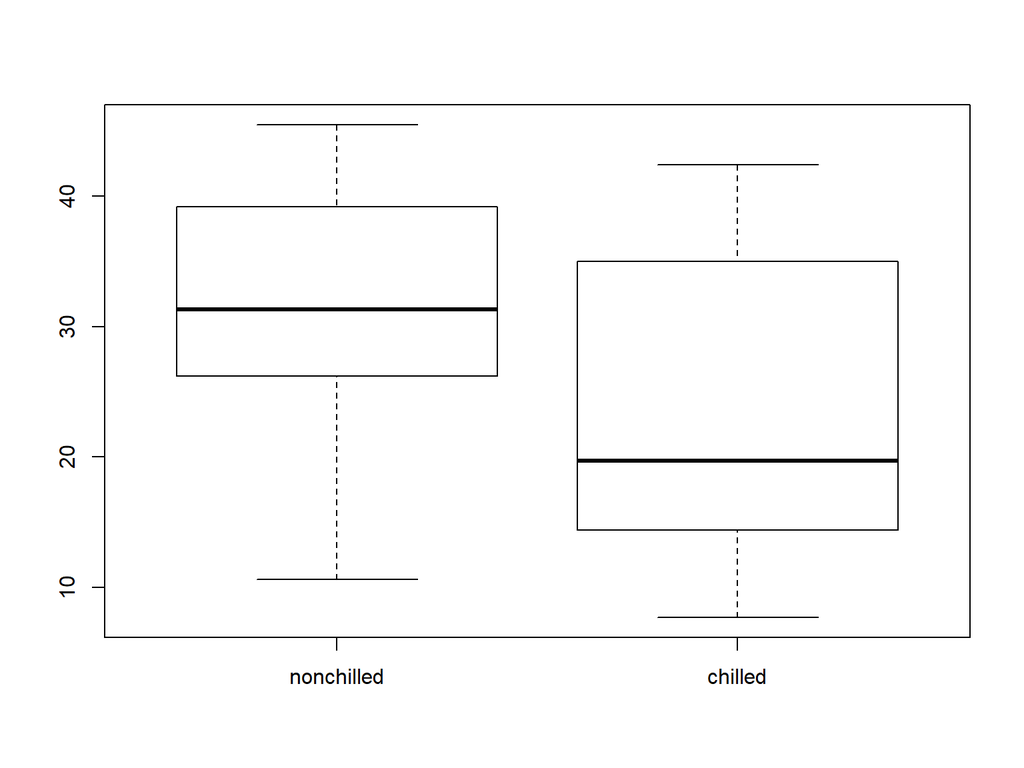

# Tests d’hypothèse

*Hypothèse nulle*: Le traitement n’a pas d’effet sur le taux d’assimilation. Selon cette hypothèse, la différence entre les deux groupes est le fruit du hasard.

Si l’hypothèse nulle était valide, quelle serait la distribution de la différence entre la moyenne du taux des deux groupes ?

On peut *simuler* l’hypothèse nulle en divisant les 84 plants en 2 groupes au hasard et en calculant la différence entre leurs moyennes. Il faut répéter ce processus de nombreuses fois afin d’obtenir une distribution.

# Tests d’hypothèse

*Hypothèse nulle*: Le traitement n’a pas d’effet sur le taux d’assimilation. Selon cette hypothèse, la différence entre les deux groupes est le fruit du hasard.

À partir de 10 000 simulations de l’hypothèse nulle, on constate que 95% résultent en une différence comprise entre -4.6 et 4.6, et seulement 18 (0.18%) résultent en une différence plus petite (donc une différence négative plus importante) que celle observée dans nos données (-6.9).

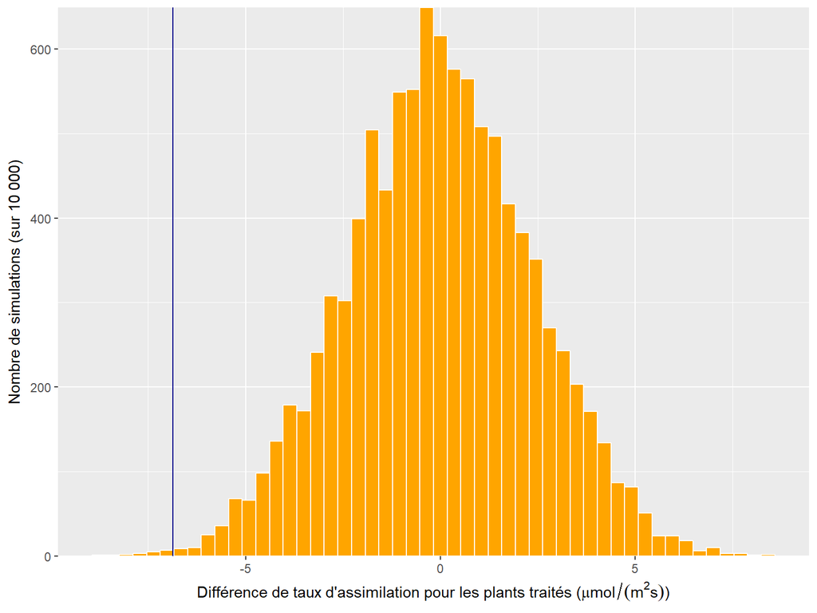

# Tests d’hypothèse

Pour cet exemple (différence entre deux moyennes), on connaît une distribution théorique correspondant à l’hypothèse nulle: la distribution *t* de Student.

Le test *t* donne un intervalle de confiance pour l’effet du traitement et la probabilité (*p-value*) qu’une différence plus importante que celle observée puisse être obtenue d’après l’hypothèse nulle.

```
##
##  Welch Two Sample t-test
##
## data:  uptake by Treatment
## t = 3.0485, df = 80.945, p-value = 0.003107
## alternative hypothesis: true difference in means is not equal to 0
## 95 percent confidence interval:
##   2.382366 11.336682
## sample estimates:
## mean in group nonchilled    mean in group chilled
##                 30.64286                 23.78333
```

**Question**: Pourquoi est-il important que les plants traités aient été choisis de façon aléatoire lors de la réalisation de l’expérience?

# Régression

Si une variable a une distribution normale dans la population, et qu’on choisit un individu $i$ au hasard sur lequel on ne connaît rien, quelle est la meilleure prédiction qu’on puisse faire sur la valeur de $y_i$?

$y_i \sim N(\mu, \sigma)$

# Régression

Si par contre on peut mesurer une autre variable $x$, qui est reliée à $y$, il est possible de prédire $y$ avec plus de précision, en estimant au préalable comment $x$ (le *prédicteur*) affecte le niveau moyen de $y$ (la *réponse*).

Dans le cas le plus simple où la relation entre les deux variables est linéaire, on obtient le modèle de régression linéaire.

$y_i \sim N(\mu_i, \sigma)$

$\mu_i = a + b x_i$

Ici, $\sigma$ représente l’écart-type de la différence entre la valeur observée de $y$ et celle prédite en fonction de $x$. Cette différence se nomme aussi *résidu*.

# Régression

## Questions

Dans le modèle de régression linéaire:

$y_i \sim N(\mu_i, \sigma)$

$\mu_i = a + b x_i$

- Comment interprète-t-on les coefficients $a$ et $b$?
- Que peut-on dire sur la valeur de $\sigma$ dans ce modèle par rapport à l’écart-type de la distribution $y$, indépendamment de $x$?

# Régression

Pour estimer les coefficients (ou paramètres) d’un modèle de régression linéaire, il faut déterminer quelles valeurs de $a$ et $b$ minimisent l’erreur résiduelle (donc $\sigma$).

*Exemple*: Régression du taux d’assimilation du CO$_2$ en fonction de la concentration de CO$_2$ ambiante, pour les données de Potvin *et al.*.

```
##
## Call:
## lm(formula = uptake ~ conc, data = CO2)
##
## Residuals:
##     Min      1Q  Median      3Q     Max
## -22.831  -7.729   1.483   7.748  16.394
##
## Coefficients:
##              Estimate Std. Error t value Pr(>|t|)
## (Intercept) 19.500290   1.853080  10.523  < 2e-16 ***
## conc         0.017731   0.003529   5.024 2.91e-06 ***
## ---
## Signif. codes:  0 '***' 0.001 '**' 0.01 '*' 0.05 '.' 0.1 ' ' 1
##
## Residual standard error: 9.514 on 82 degrees of freedom
## Multiple R-squared:  0.2354, Adjusted R-squared:  0.2261
## F-statistic: 25.25 on 1 and 82 DF,  p-value: 2.906e-06
```

# Régression - Valider le modèle

Est-ce que le modèle linéaire est réaliste pour ces données?

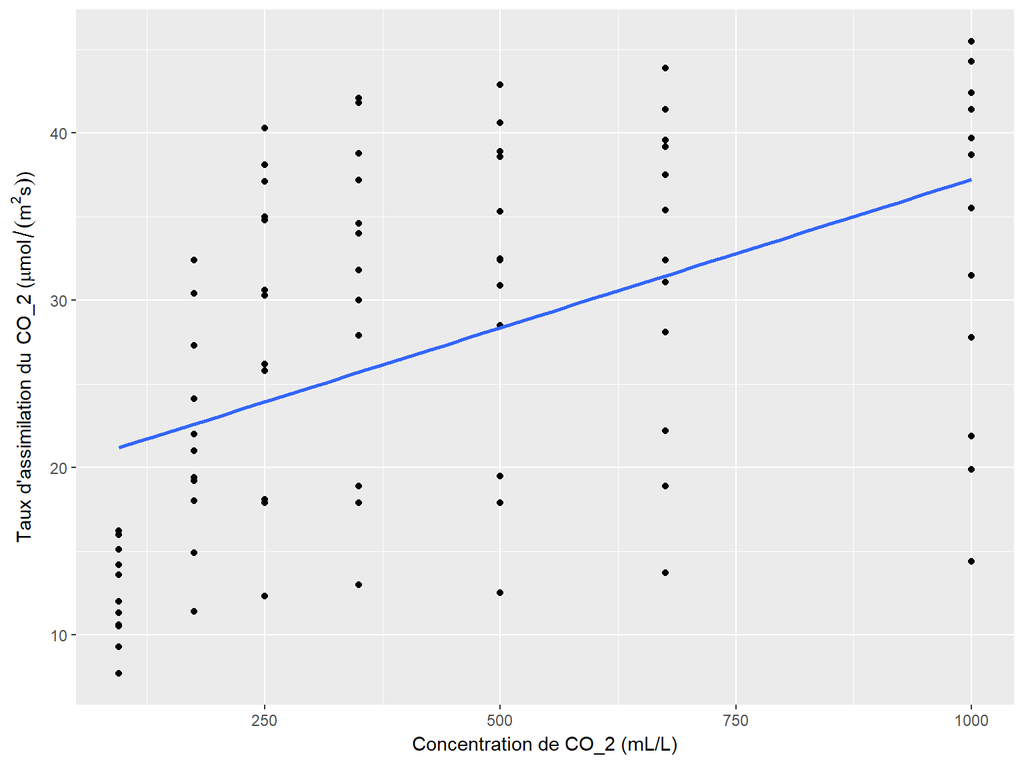

# Régression - Valider le modèle

Vérifier l’absence de patron dans les résidus.

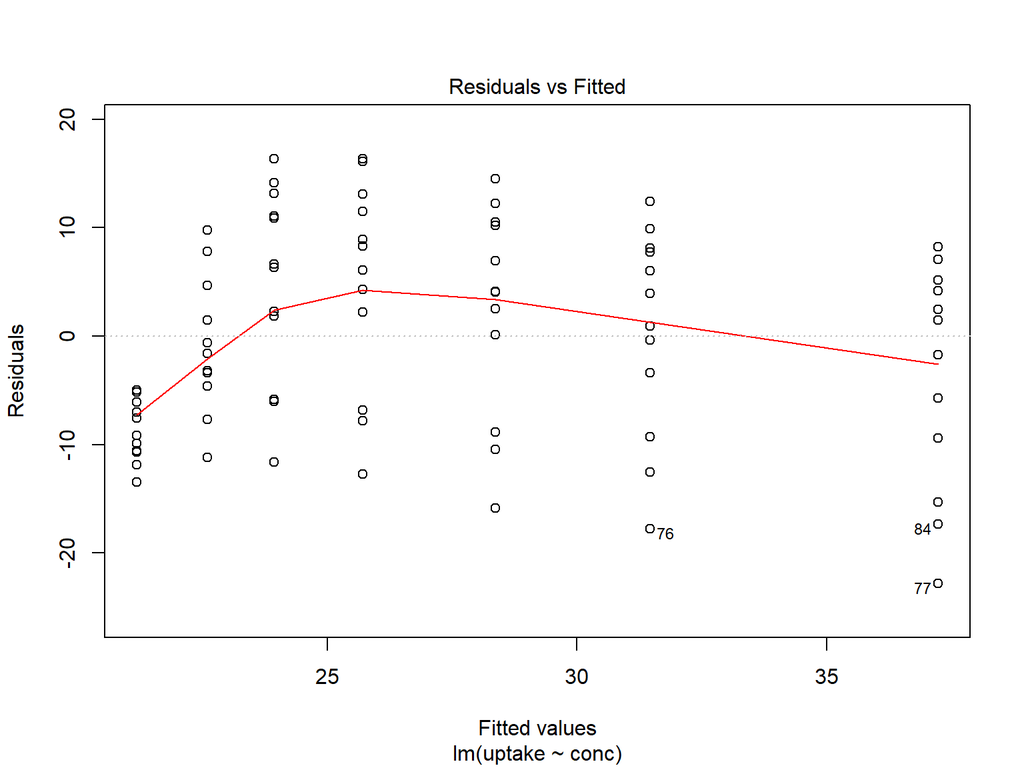

# Régression et différence entre groupes

En plus de variables numériques, on peut utiliser des prédicteurs binaires ou catégoriques. Ainsi, la question de l’effet du traitement sur le taux d’assimilation peut être présentée sous forme de régression.

```
##
## Call:
## lm(formula = uptake ~ Treatment, data = CO2)
##
## Residuals:
##      Min       1Q   Median       3Q      Max
## -20.0429  -8.6530  -0.4429   9.7321  18.6167
##
## Coefficients:
##                  Estimate Std. Error t value Pr(>|t|)
## (Intercept)        30.643      1.591  19.259   <2e-16 ***
## Treatmentchilled   -6.860      2.250  -3.048   0.0031 **
## ---
## Signif. codes:  0 '***' 0.001 '**' 0.01 '*' 0.05 '.' 0.1 ' ' 1
##
## Residual standard error: 10.31 on 82 degrees of freedom
## Multiple R-squared:  0.1018, Adjusted R-squared:  0.09084
## F-statistic: 9.293 on 1 and 82 DF,  p-value: 0.003096
```

# Régression et différence entre groupes

En plus de variables numériques, on peut utiliser des prédicteurs binaires ou catégoriques. Ainsi, la question de l’effet du traitement sur le taux d’assimilation peut être présentée sous forme de régression.

```
##
## Call:
## lm(formula = uptake ~ Treatment, data = CO2)
##
## Residuals:
##      Min       1Q   Median       3Q      Max
## -20.0429  -8.6530  -0.4429   9.7321  18.6167
##
## Coefficients:
##                  Estimate Std. Error t value Pr(>|t|)
## (Intercept)        30.643      1.591  19.259   <2e-16 ***
## Treatmentchilled   -6.860      2.250  -3.048   0.0031 **
## ---
## Signif. codes:  0 '***' 0.001 '**' 0.01 '*' 0.05 '.' 0.1 ' ' 1
##
## Residual standard error: 10.31 on 82 degrees of freedom
## Multiple R-squared:  0.1018, Adjusted R-squared:  0.09084
## F-statistic: 9.293 on 1 and 82 DF,  p-value: 0.003096
```

Le résultat est identique à celui du test *t* précédent:

```
##
##  Welch Two Sample t-test
##
## data:  uptake by Treatment
## t = 3.0485, df = 80.945, p-value = 0.003107
## alternative hypothesis: true difference in means is not equal to 0
## 95 percent confidence interval:
##   2.382366 11.336682
## sample estimates:
## mean in group nonchilled    mean in group chilled
##                 30.64286                 23.78333
```

# Régression

Différence entre intervalle de confiance (pour un paramètre de la population) et intervalle de prédiction (pour des observations individuelles).

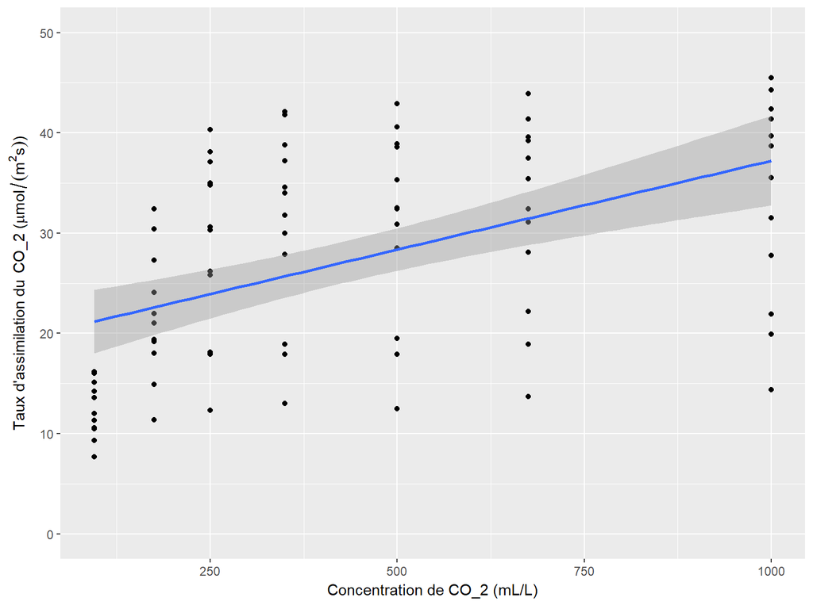

# Régression

Différence entre intervalle de confiance (pour un paramètre de la population) et intervalle de prédiction (pour des observations individuelles).

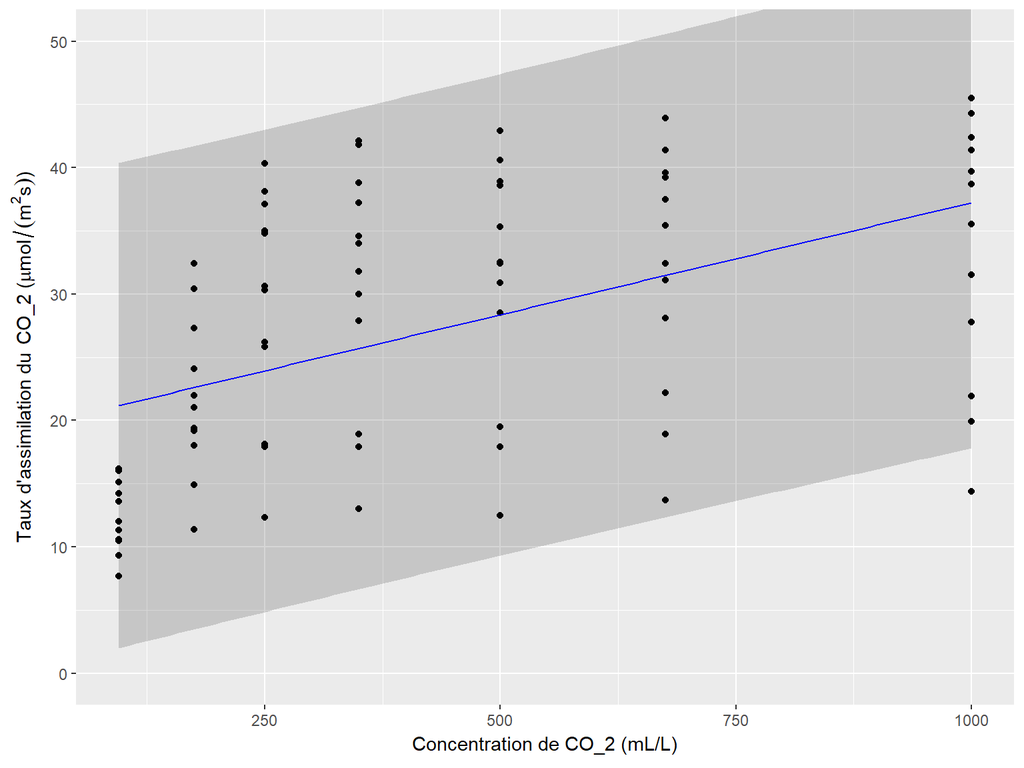

# Régression

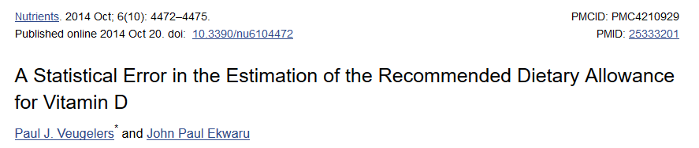

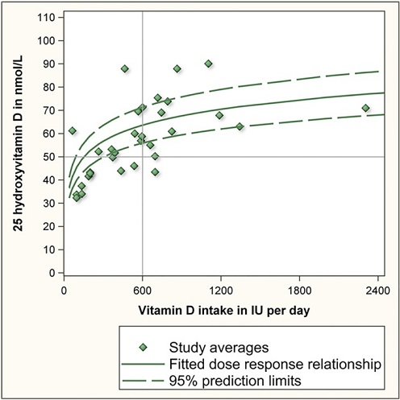

# Résumé

- Décrire la distribution d’une variable
  - Statistiques descriptives et représentations graphiques
- Estimer les paramètres d’un modèle statistique
  - Moyenne d’un échantillon, différence entre moyennes, paramètres de régression
  - Erreur-type et intervalle de confiance
- Tester une hypothèse à partir de données expérimentales
  - Hypothèse nulle
  - *p-value*
- Prédire la valeur d’une variable pour une nouvelle observation
  - Intervalle de prédiction
  - Biais vs. variance

# Points à surveiller

- Influence des valeurs extrêmes
- Significativité vs. importance

[figure not shown]

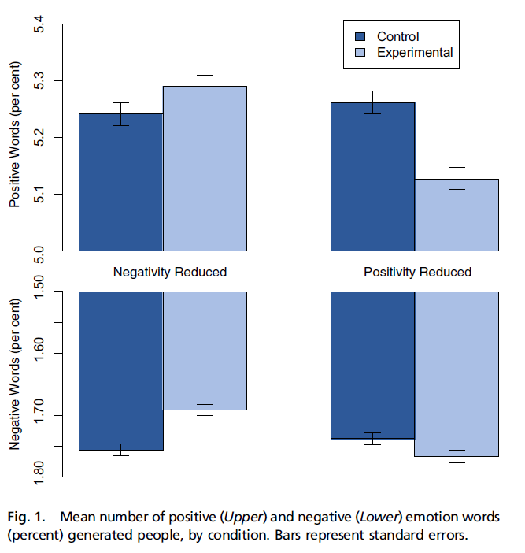

# Importance relative ou absolue

Exemple: Lequel des scénarios a le plus grand impact?

- Augmentation de 10% du risque d’une maladie touchant 20% de la population.
- Multiplication par 2 du risque d’une maladie affectant 1% de la population.

# Points à surveiller

- Influence des valeurs extrêmes
- Significativité vs. importance
- Attention aux comparaisons multiples
- Le meilleur modèle n’est peut-être pas assez bon (valider, pas juste comparer)
- Corrélation entre deux variables dépend de la population